# maps package

17. Juli 2015

## Political Map:

- A political map does not show any topographic features.
- It focuses on the state and national boundaries of a place.
- Include locations of cities - both large and small, depending on the detail of the map.
- A common type of political map would be one showing the 50 U.S. states and their borders along with the United States' north and south international borders (map of the United States).

## Choropleth maps

[interactive chart not shown]

## The maps package

```r
library(maps)
```

How to get help

```r
?map
```

## A first map

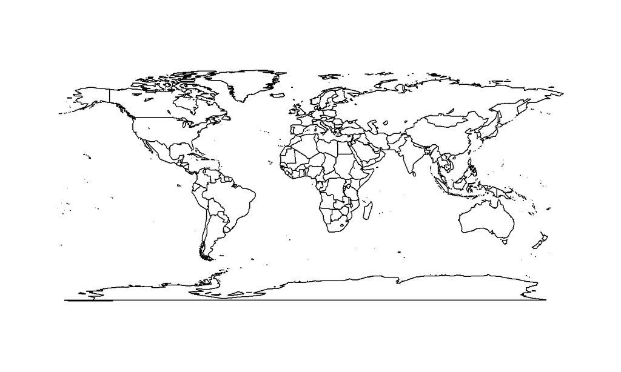

```r
map()
```

## A first argument

The same command with an argument:

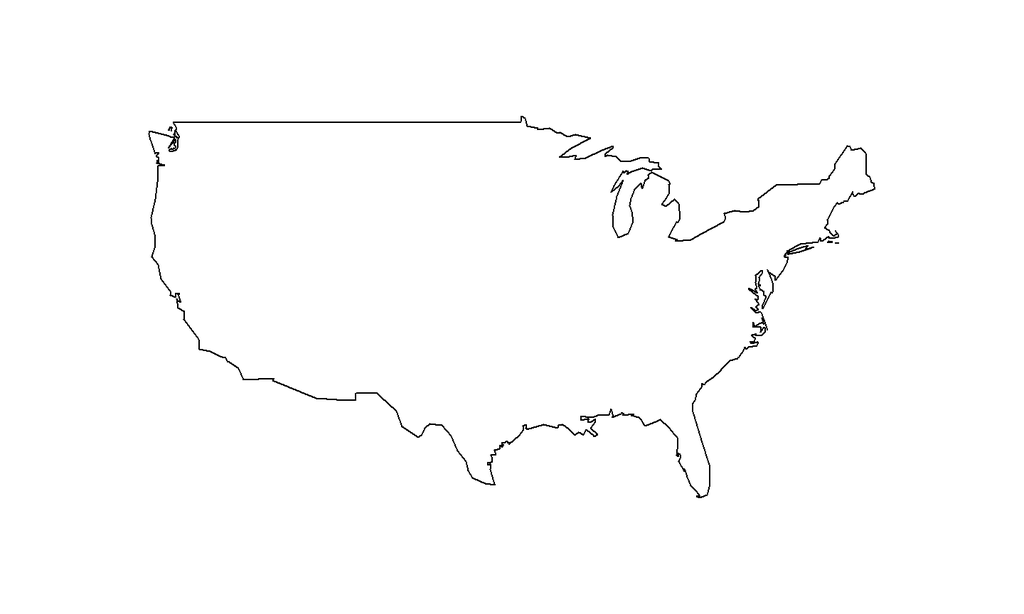

```r
map("usa")
```

## A map of france

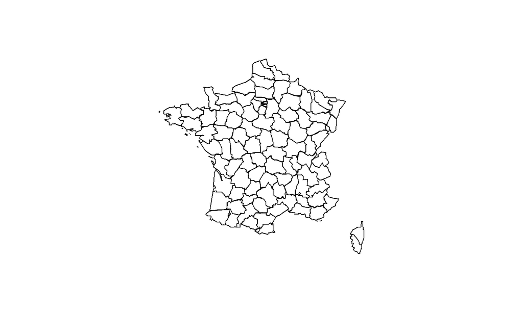

```r
map("france")
```

## Choropleths - package maps

Get the borders in blue color:

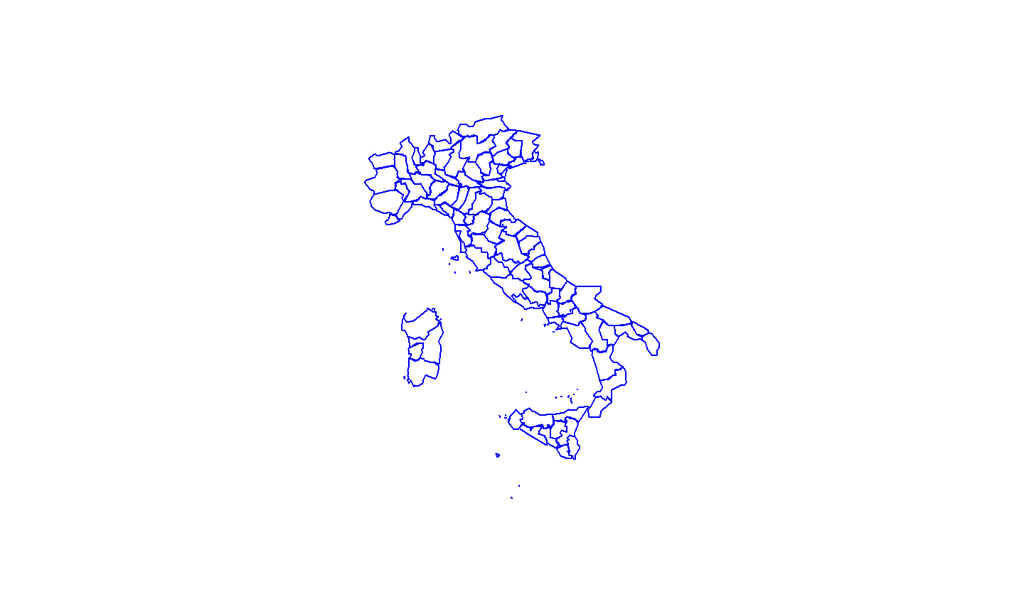

```r
library ( maps )
map ("italy", col = "blue")
```

## Choropleths - package maps

If we want the areas in blue:

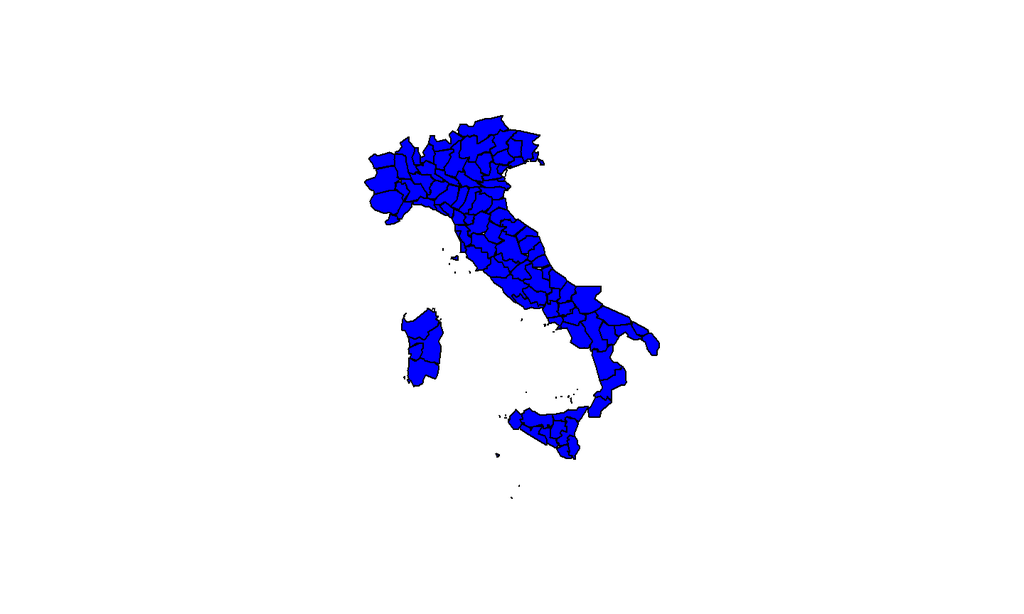

```r
map ("italy",fill =T, col = "blue")
```

## More colors

Create a vector:

```r
colors <- c("blue","red","yellow")
```

and use the vector to specify the color

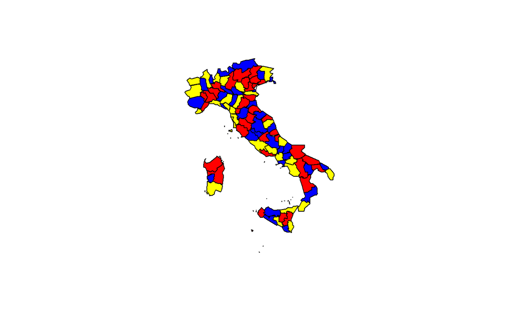

```r
map ("italy",fill =T, col = colors)
```

## Excursus: more colors!

You can also use the [rgb](https://stat.ethz.ch/R-manual/R-devel/library/grDevices/html/rgb.html) command to create your own colors:

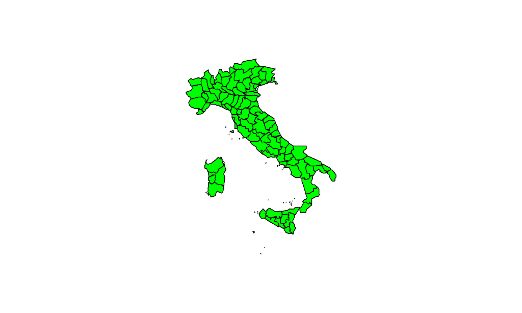

```r
map("italy",fill=T, col = rgb(0,1,0))
```

## Try also

```r
map("italy",fill=T, col = rgb(1,0,0))
map("italy",fill=T, col = rgb(1,1,1))
map("italy",fill=T, col = rgb(1,0.5,0.4))
```

## Choropleths - package maps

If you want to know, which region is at which place:

```r
italy <- map("italy", plot = F)
head(italy$names)
```

```
## [1] "Bolzano-Bozen" "Belluno"       "Udine"         "Sondrio"
## [5] "Trento"        "Novara"
```

## A map for Germany

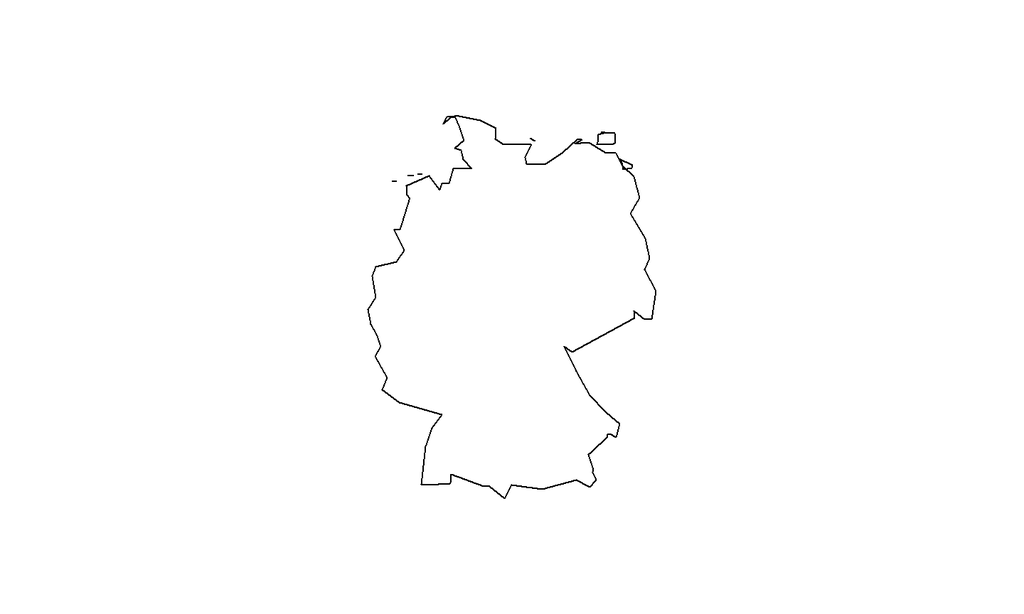

```r
library(maps)
map("world", "Germany")
```

## Choropleths - package maps - two countries

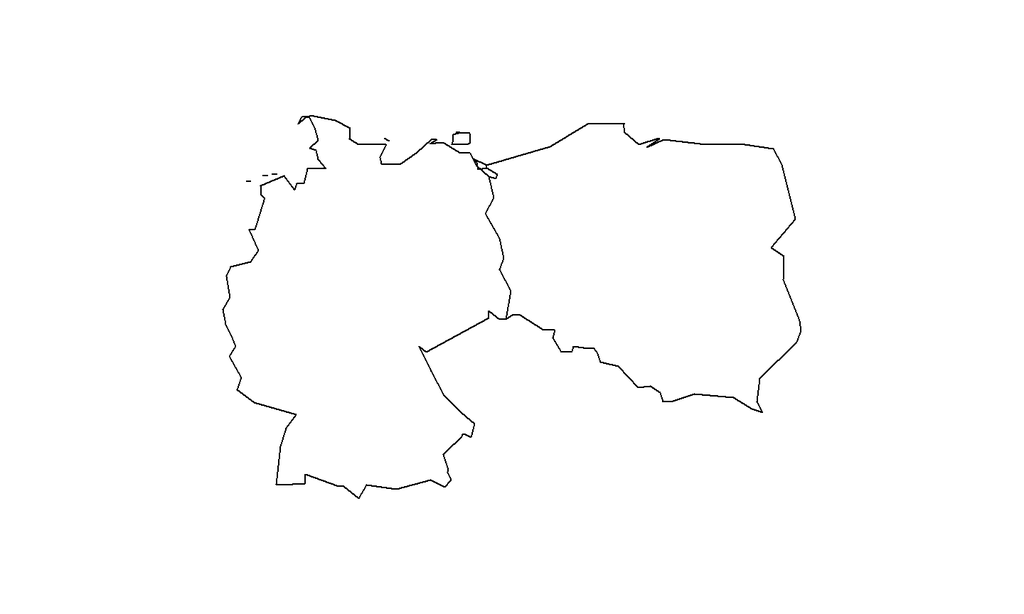

```r
map("world", c("Germany","Poland"))
```

## 2 countries with color

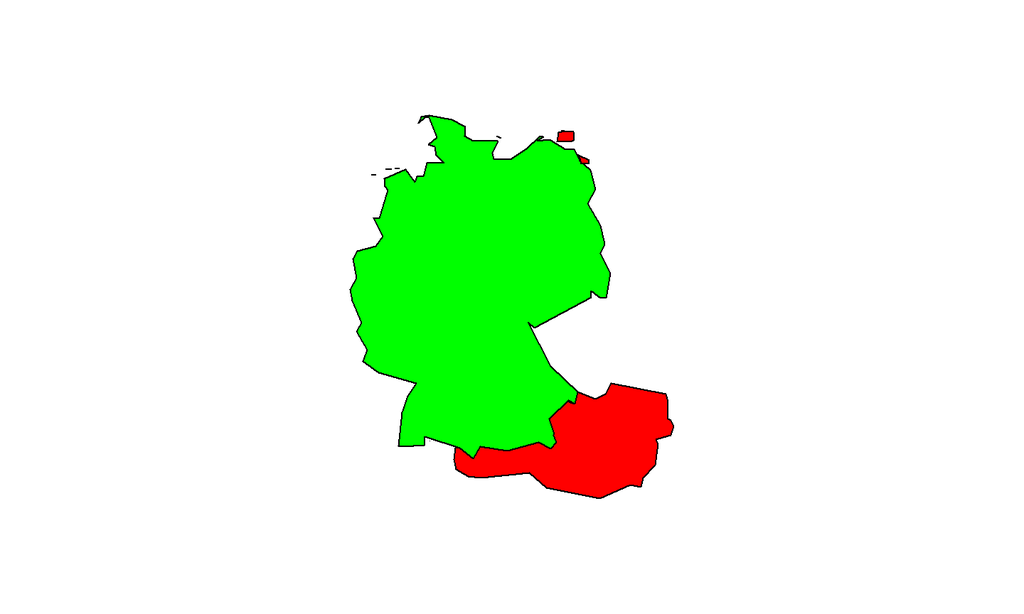

```r
map("world", c("Germany","Austria"),fill=T,
col=c("red","green"))
```

## Choropleths - package maps - additional features

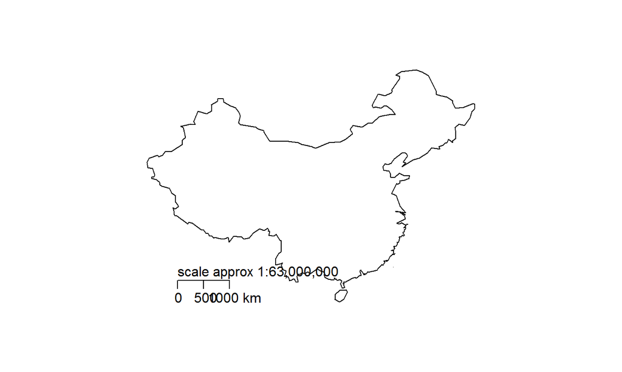

```r
map("world", "China")
map.scale()
```

## Choropleths - package maps - additional features

Like `map`, but labels the regions:

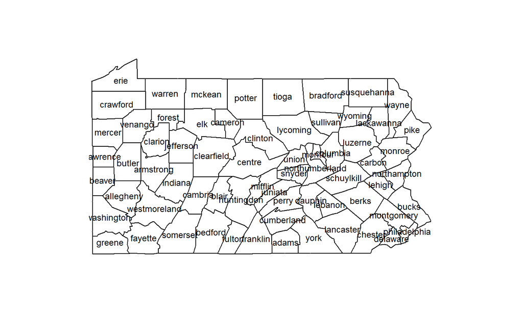

```r
map.text("county", "penn")
```

Pennsylvania counties

## R-package maps - World cities

`data` loads specified data sets, or lists the available data sets.

```r
data(world.cities)
```

`head` - Return the First Part of an Object

```r
head(world.cities)
```

## Overview of world cities data

| name | country.etc | pop | lat | long | capital |
| --- | --- | --- | --- | --- | --- |
| 'Abasan al-Jadidah | Palestine | 5629 | 31.31 | 34.34 | 0 |
| 'Abasan al-Kabirah | Palestine | 18999 | 31.32 | 34.35 | 0 |
| 'Abdul Hakim | Pakistan | 47788 | 30.55 | 72.11 | 0 |
| 'Abdullah-as-Salam | Kuwait | 21817 | 29.36 | 47.98 | 0 |
| 'Abud | Palestine | 2456 | 32.03 | 35.07 | 0 |
| 'Abwein | Palestine | 3434 | 32.03 | 35.20 | 0 |

## Map the cities of the world

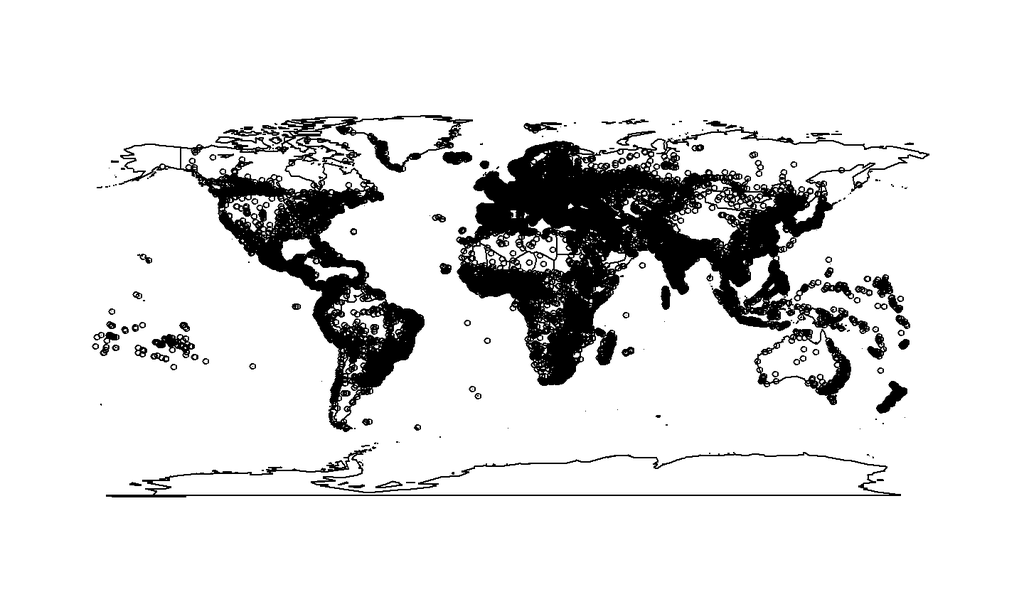

```r
map()
map.cities(world.cities)
```

## Cities of France

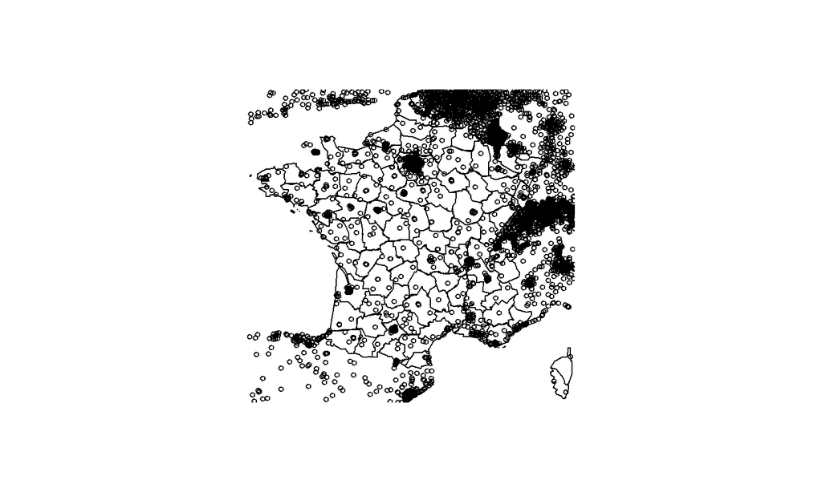

```r
data(world.cities)
map("france")
map.cities(world.cities)
```

## Only cities of France

```r
FrenchCity <- world.cities$country.etc=="France"
FCit <- world.cities[FrenchCity,]
```

|  | name | country.etc | pop | lat | long | capital |
| --- | --- | --- | --- | --- | --- | --- |
| 195 | Abbeville | France | 26656 | 50.12 | 1.83 | 0 |
| 318 | Acheres | France | 23219 | 48.97 | 2.06 | 0 |
| 477 | Agde | France | 23477 | 43.33 | 3.46 | 0 |
| 479 | Agen | France | 34742 | 44.20 | 0.62 | 0 |

## Only cities of France

Now it is possible to map only the french cities:

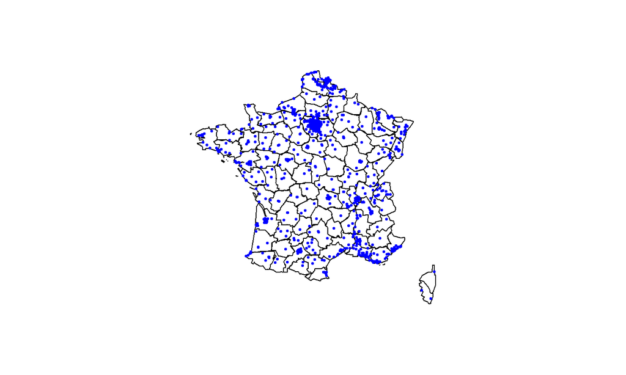

```r
map("france")
map.cities(FCit,col="blue",pch=20)
```

`pch` - plotting character, i.e., symbol to use.

## Different sizes - different colors

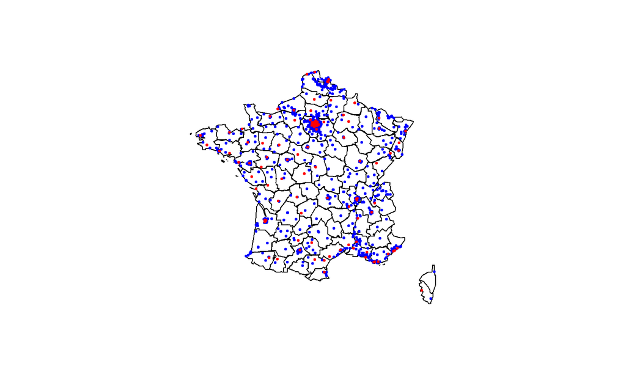

```r
FCit_Bc<-FCit[FCit$pop>50000,]
map("france")
map.cities(FCit,col="blue",pch=20)
map.cities(FCit_Bc,col="red",pch=20)
```

## Data basis - CIA World DataBank II

The [CIA World DataBank](http://www.evl.uic.edu/pape/data/WDB/) is a collection of world map data, consisting of vector descriptions of land outlines, rivers, / political boundaries. It was created by U.S. government in the 1980s.

## Example: US Unemployment

- [More](http://bcb.dfci.harvard.edu/~aedin/courses/R/CDC/maps.html) about the usage of package maps

Get the data:

```r
library(maps)
data(unemp)
data(county.fips)
```

## Colour gradients

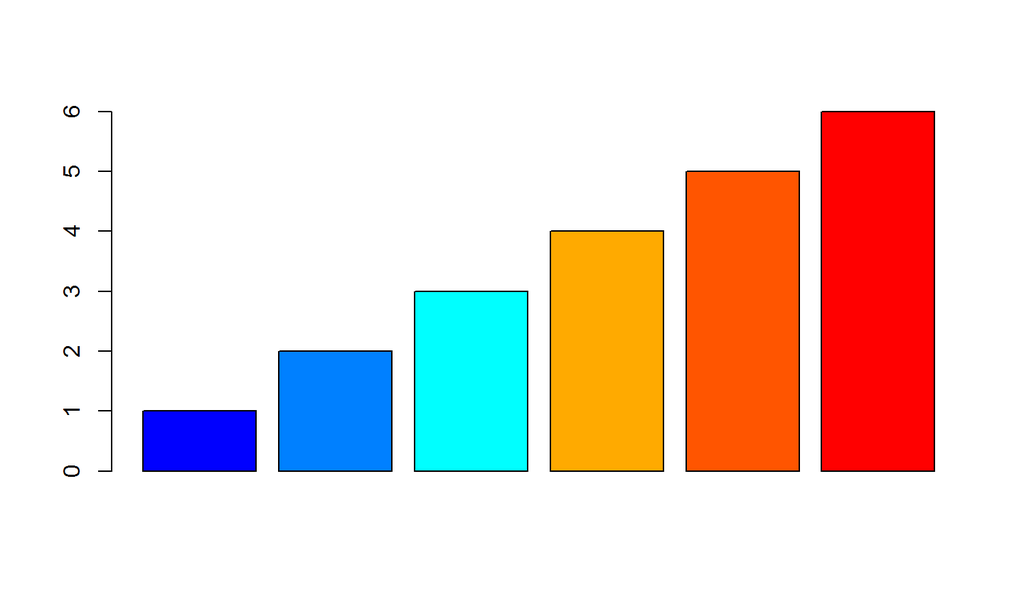

```r
library(colorRamps)
colors <- blue2red(6)
barplot(1:6,col=colors)
```

## Example: US Unemployment

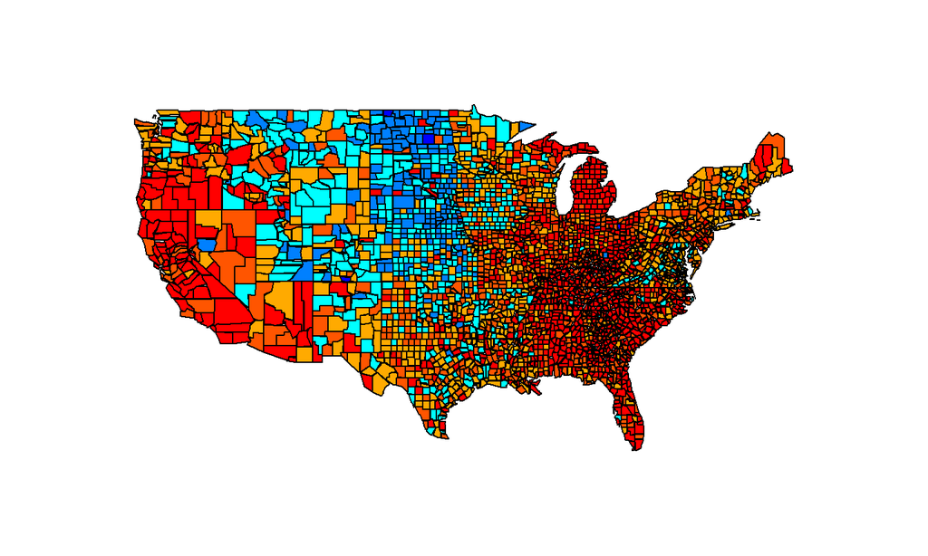

```r
unemp$colorSteps <- cut(unemp$unemp, c(0, 2, 4, 6, 8,10, 100))
colorsmatch <- unemp$colorSteps[match(county.fips$fips, unemp$fips)]

map("county", col = colors[colorsmatch], fill = TRUE)
```

## Further links and resources

- [Using R — Working with Geospatial Data](http://mazamascience.com/WorkingWithData/?p=1277)